# Report

Silvia Ferrer and Ignacio Lloret

2023-11-27

# Data Preparation

## Missing data and Errors

Firstly, we removed possible duplicates from the dataset using the distinct function. Then, we factorized the variable SeniorCitizen, as it only has two categories. We then excluded the customerID variable since it is a unique categorical identifier that is not useful for the model, and analyzing its data distribution does not provide meaningful insights.

Checking the missing data in the dataset and which variables have NA’s we can see that the ones with missing values is TotalCharges. Investigating the observations with missing values to understand the underlying reason, we found that all these observations have tenure=0. We decided that the most appropriate option is to manually impute these TotalCharges with 0. If the tenure is 0, it implies that the contract has not started, indicating no debt or amount to be paid. We validated the imputation using density plots and confirmed that the distribution remained unchanged. Therefore, we proceeded with these imputed values.

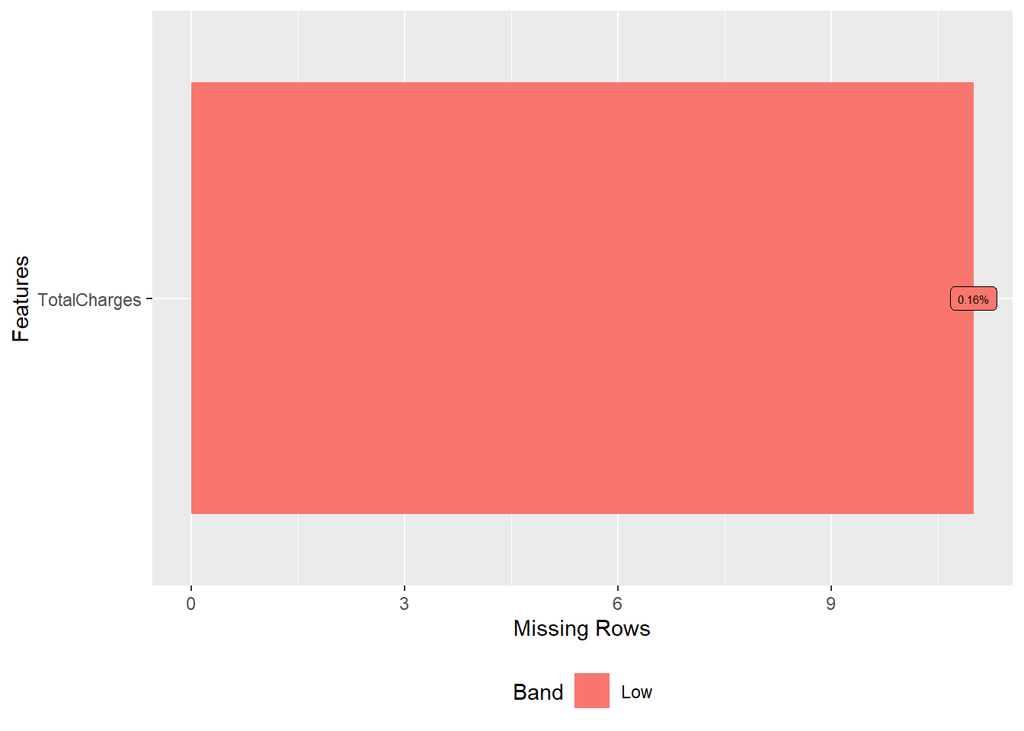

```r
#, fig.height=1.5

# Duplicates observations
df1 <- distinct(df1, .keep_all = TRUE)

# Numeric to factor SeniorCitizen
df1$SeniorCitizen <- df1$SeniorCitizen %>% as.factor()

# Take off the variable customerID
df1 <- subset(df1, select = -customerID)

cat_keep <- names(df1)[sapply(df1, function(x) is.character(x))]
numeric_columns <-  names(df1)[sapply(df1, function(x) is.numeric(x))]

df1[cat_keep] <- lapply(df1[cat_keep], as.factor) ## Create Factors
df1[numeric_columns] <- lapply(df1[numeric_columns], as.numeric)

# Missing values
plot_missing(df1, missing_only = TRUE, group = list("Low" = 0.05, "Medium"=0.25, "High"=0.5, "Very High" =1), geom_label_args = list("size" = 2))
```

```r
observaciones_na <- df1 %>% filter(is.na(TotalCharges))
print(observaciones_na$tenure)
```

```
##  [1] 0 0 0 0 0 0 0 0 0 0 0
```

```r
# Errors or inconsistencies -> imputed
df2 <- df1
df2$TotalCharges <- ifelse(is.na(df2$TotalCharges) & df2$tenure == 0, 0, df2$TotalCharges)

# validation
summary(df2$TotalCharges)
```

```
##    Min. 1st Qu.  Median    Mean 3rd Qu.    Max.
##     0.0   398.6  1394.5  2279.7  3786.6  8684.8
```

```r
summary(df1$TotalCharges)
```

```
##    Min. 1st Qu.  Median    Mean 3rd Qu.    Max.    NA's
##    18.8   401.4  1397.5  2283.3  3794.7  8684.8      11
```

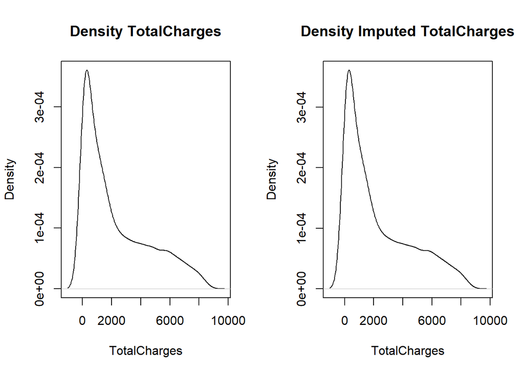

```r
par(mfrow=c(1,2))
plot(density(df1$TotalCharges,na.rm=TRUE), main = "Density TotalCharges",
     xlab = "TotalCharges", ylab = "Density")
plot(density(df2$TotalCharges,na.rm=TRUE), main = "Density Imputed TotalCharges",
     xlab = "TotalCharges", ylab = "Density")
```

```r
#inconsistencias con el No phone service o No internet service
summary(df2) # misma frec de no phone y internet service en las variables
```

```
##     gender     SeniorCitizen Partner    Dependents     tenure      PhoneService
##  Female:3488   0:5901        No :3641   No :4933   Min.   : 0.00   No : 682
##  Male  :3555   1:1142        Yes:3402   Yes:2110   1st Qu.: 9.00   Yes:6361
##                                                    Median :29.00
##                                                    Mean   :32.37
##                                                    3rd Qu.:55.00
##                                                    Max.   :72.00
##           MultipleLines     InternetService             OnlineSecurity
##  No              :3390   DSL        :2421   No                 :3498
##  No phone service: 682   Fiber optic:3096   No internet service:1526
##  Yes             :2971   No         :1526   Yes                :2019
##
##
##
##               OnlineBackup             DeviceProtection
##  No                 :3088   No                 :3095
##  No internet service:1526   No internet service:1526
##  Yes                :2429   Yes                :2422
##
##
##
##               TechSupport                StreamingTV
##  No                 :3473   No                 :2810
##  No internet service:1526   No internet service:1526
##  Yes                :2044   Yes                :2707
##
##
##
##             StreamingMovies           Contract    PaperlessBilling
##  No                 :2785   Month-to-month:3875   No :2872
##  No internet service:1526   One year      :1473   Yes:4171
##  Yes                :2732   Two year      :1695
##
##
##
##                    PaymentMethod  MonthlyCharges    TotalCharges    Churn
##  Bank transfer (automatic):1544   Min.   : 18.25   Min.   :   0.0   No :5174
##  Credit card (automatic)  :1522   1st Qu.: 35.50   1st Qu.: 398.6   Yes:1869
##  Electronic check         :2365   Median : 70.35   Median :1394.5
##  Mailed check             :1612   Mean   : 64.76   Mean   :2279.7
##                                   3rd Qu.: 89.85   3rd Qu.:3786.6
##                                   Max.   :118.75   Max.   :8684.8
```

# Variable analysis

## Categorical values

To analyze the categorical variables, we have depicted a barplot for each of them in the figure below.

One of the most relevant observations is that our response variable, Churn, is unbalanced, with significantly more negative cases than positive ones.

[figure not shown]

```r
p1 <- df2 %>%
  select(all_of(cat_keep)) %>%
  pivot_longer(cols=everything()) %>%
  ggplot(data=.) +
  geom_bar(aes(x=value), col="black", fill="white") +
  theme(axis.text.x = element_text(angle = 45, hjust = 1)) +
  facet_wrap(~name, scales="free", ncol=4)
p1
```

## Numerical Data

In order to analyze the numerical variables, we have represented a boxplot for each of them in the figure below. Notably, none of them show univariate outliers.

Subsequently, we discretized each variable into four quartiles and represented them as factors. We displayed their frequency tables to verify that the data is appropriately distributed across each category.

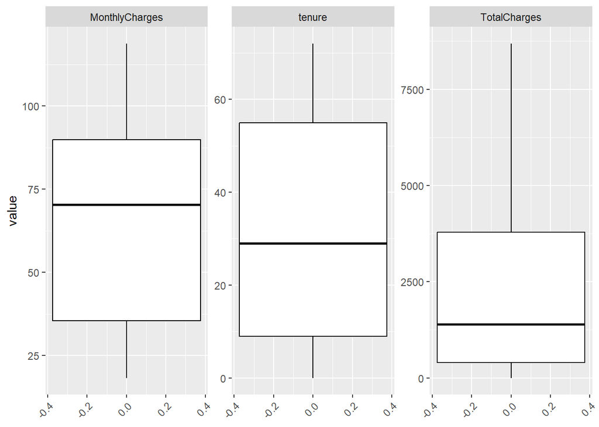

```r
#, fig.height=20
p2 <- df2 %>%
  select(all_of(numeric_columns)) %>%
  pivot_longer(cols=everything()) %>%
  ggplot(data=.) +
  geom_boxplot(aes(y=value), col="black", fill="white") +
  theme(axis.text.x = element_text(angle = 45, hjust = 1)) +
  facet_wrap(~name, scales="free", ncol=4)
p2
```

```r
# Create a discretization of numeric variables
sm <- summary(df2$tenure)
df2$f.tenure <- ifelse(df2$tenure <= sm["1st Qu."], 1,
               ifelse(df2$tenure > sm["1st Qu."] & df2$tenure <= sm["Mean"], 2,
               ifelse(df2$tenure > sm["Mean"] & df2$tenure <= sm["3rd Qu."], 3,
               ifelse(df2$tenure > sm["3rd Qu."], 4,0))))
df2$f.tenure <- factor(df2$f.tenure, labels=c("LowTenure","LowMidTenure","HighMidTenure","HighTenure"), order = T, levels=c(1,2,3,4))
table(df2$f.tenure)
```

```
##
##     LowTenure  LowMidTenure HighMidTenure    HighTenure
##          1854          1921          1513          1755
```

```r
sm <- summary(df2$MonthlyCharges)
df2$f.MonthlyCharges <- ifelse(df2$MonthlyCharges <= sm["1st Qu."], 1,
               ifelse(df2$MonthlyCharges > sm["1st Qu."] & df2$MonthlyCharges <= sm["Mean"], 2,
               ifelse(df2$MonthlyCharges > sm["Mean"] & df2$MonthlyCharges <= sm["3rd Qu."], 3,
               ifelse(df2$MonthlyCharges > sm["3rd Qu."], 4,0))))
df2$f.MonthlyCharges <- factor(df2$f.MonthlyCharges, labels=c("LowMonthlyCharges","LowMidMonthlyCharges","HighMidMonthlyCharges","HighMonthlyCharges"), order = T, levels=c(1,2,3,4))
table(df2$f.MonthlyCharges)
```

```
##
##     LowMonthlyCharges  LowMidMonthlyCharges HighMidMonthlyCharges
##                  1762                  1358                  2165
##    HighMonthlyCharges
##                  1758
```

```r
sm <- summary(df2$TotalCharges)
df2$f.TotalCharges <- ifelse(df2$TotalCharges <= sm["1st Qu."], 1,
               ifelse(df2$TotalCharges > sm["1st Qu."] & df2$TotalCharges <= sm["Mean"], 2,
               ifelse(df2$TotalCharges > sm["Mean"] & df2$TotalCharges <= sm["3rd Qu."], 3,
               ifelse(df2$TotalCharges > sm["3rd Qu."], 4,0))))
df2$f.TotalCharges <- factor(df2$f.TotalCharges, labels=c("LowTotalCharges","LowMidTotalCharges","HighMidTotalCharges","HighTotalCharges"), order = T, levels=c(1,2,3,4))
table(df2$f.TotalCharges)
```

```
##
##     LowTotalCharges  LowMidTotalCharges HighMidTotalCharges    HighTotalCharges
##                1762                2632                 888                1761
```

# Data Quality Report

## Multivariate outliers

In the initial analysis of multivariate outliers, a significance level of 0.05% was chosen as a very mild threshold. However, the vertical threshold is not visible on the graph as it extends beyond its limits. It is evident that there are no multivariate outliers beyond this threshold. We opted not to set a higher significance level because the observations are very grouped and there is no apparent clear outlier that warrants removal from the dataset.

```r
df_of_interest <- df2[,c(numeric_columns)]

res.out = Moutlier(df_of_interest, quantile = 0.9995, col="green")
```

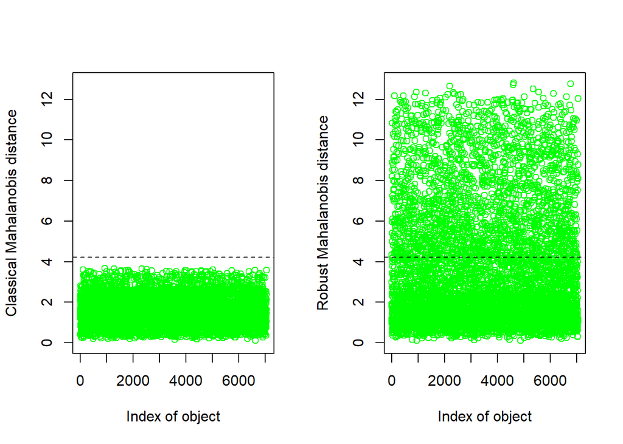

```r
which((res.out$md > res.out$cutoff)&(res.out$rd > res.out$cutoff))
```

```
## named integer(0)
```

```r
length(which((res.out$md > res.out$cutoff)&(res.out$rd > res.out$cutoff)))
```

```
## [1] 0
```

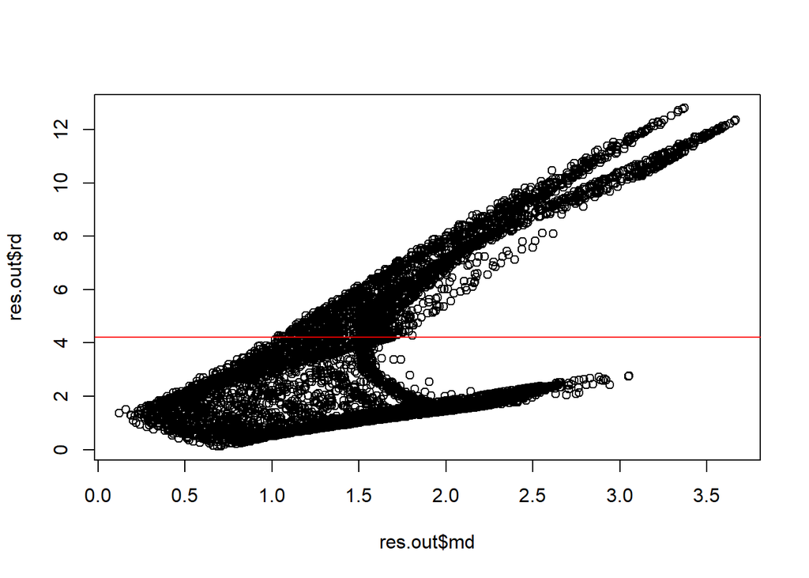

```r
par(mfrow=c(1,1))
plot( res.out$md, res.out$rd )
abline(h=res.out$cutoff, col="red")
abline(v=res.out$cutoff, col="red")
```

```r
#summary(df2[which((res.out$md > res.out$cutoff)&(res.out$rd > res.out$cutoff)),])
#summary(df2)

#df2 = df2[-which((res.out$md > res.out$cutoff)&(res.out$rd > res.out$cutoff)),]
```

## Data Quality Report

As we have seen before, there are no univariate outliers, therefore, we have left the column empty, although it is represented to consider it as a parameter in the total quality sum. To measure missing values, we have conducted a column count, although we had already seen in the first section that the only column with missing values was TotalCharges, we have taken the values from the not imputed dataframe. Additionally, we consider it an error if the dataset has the tenure value equal to 0. Taking these metrics into account, we observe that the two variables with lower quality are tenure and TotalCharges. We do not believe it is necessary to look at another analysis per individuals to see the correlation with the variables because the two most related variables have been very explicitly identified in the analysis per variable.

### Per variable

```r
dq <- data.frame(colnames(df1[, 1:20]))
dq$outliers <- 0
dq$missing <- 0
dq$errors <- 0

dq$missing <- (colSums(is.na(df1[, 1:20])))
dq$errors[dq$colnames=="tenure"] <- sum(ifelse(df1$tenure == 0, 1, 0))
dq$quality <- dq$outliers + dq$missing + dq$errors
dq
```

```
##    colnames.df1...1.20.. outliers missing errors quality
## 1                 gender        0       0      0       0
## 2          SeniorCitizen        0       0      0       0
## 3                Partner        0       0      0       0
## 4             Dependents        0       0      0       0
## 5                 tenure        0       0     11      11
## 6           PhoneService        0       0      0       0
## 7          MultipleLines        0       0      0       0
## 8        InternetService        0       0      0       0
## 9         OnlineSecurity        0       0      0       0
## 10          OnlineBackup        0       0      0       0
## 11      DeviceProtection        0       0      0       0
## 12           TechSupport        0       0      0       0
## 13           StreamingTV        0       0      0       0
## 14       StreamingMovies        0       0      0       0
## 15              Contract        0       0      0       0
## 16      PaperlessBilling        0       0      0       0
## 17         PaymentMethod        0       0      0       0
## 18        MonthlyCharges        0       0      0       0
## 19          TotalCharges        0      11      0      11
## 20                 Churn        0       0      0       0
```

# Profiling and Feature Selection

## Interactions between the target and other variables

The results from FactoMinerR::catdes() show the relationship between the variable Churn and both categorical and quantitative variables.

The variable Churn is also described by the categories. For the ‘No’ cluster, the categories with the highest v.test values (indicating a strong association) are ‘Contract=Two year’, ‘f.tenure=HighTenure’, and ‘StreamingMovies=No internet service’. For the ‘Yes’ cluster, the categories with the highest v.test values are ‘Contract=Month-to-month’, ‘OnlineSecurity=No’, and ‘TechSupport=No’.

For quantitative variables, the Eta2 statistic was used. The variable ‘tenure’ has the highest Eta2 value, indicating it has the strongest association with the cluster variable. The p-values for all variables are extremely small, indicating a significant association.

The variable Churn is also described by the quantitative variables. For the ‘No’ cluster, the variable with the highest v.test value (indicating a strong association) is ‘tenure’. For the ‘Yes’ cluster, the variable with the highest v.test value is ‘MonthlyCharges’.

```r
catdes(df2, num.var=which(names(df2) == 'Churn'))
```

```
##
## Link between the cluster variable and the categorical variables (chi-square test)
## =================================================================================
##                        p.value df
## Contract         5.863038e-258  2
## f.tenure         1.523011e-192  3
## OnlineSecurity   2.661150e-185  2
## TechSupport      1.443084e-180  2
## InternetService  9.571788e-160  2
## PaymentMethod    3.682355e-140  3
## OnlineBackup     2.079759e-131  2
## DeviceProtection 5.505219e-122  2
## f.TotalCharges    4.965119e-85  3
## StreamingMovies   2.667757e-82  2
## StreamingTV       5.528994e-82  2
## f.MonthlyCharges  4.505436e-76  3
## PaperlessBilling  2.614597e-58  1
## Dependents        3.276083e-43  1
## SeniorCitizen     9.477904e-37  1
## Partner           1.519037e-36  1
## MultipleLines     3.464383e-03  2
##
## Description of each cluster by the categories
## =============================================
## $No
##                                          Cla/Mod  Mod/Cla   Global
## Contract=Two year                       97.16814 31.83224 24.06645
## f.tenure=HighTenure                     92.25071 31.29107 24.91836
## StreamingMovies=No internet service     92.59502 27.30963 21.66690
## StreamingTV=No internet service         92.59502 27.30963 21.66690
## TechSupport=No internet service         92.59502 27.30963 21.66690
## DeviceProtection=No internet service    92.59502 27.30963 21.66690
## OnlineBackup=No internet service        92.59502 27.30963 21.66690
## OnlineSecurity=No internet service      92.59502 27.30963 21.66690
## InternetService=No                      92.59502 27.30963 21.66690
## f.MonthlyCharges=LowMonthlyCharges      88.76277 30.22806 25.01775
## PaperlessBilling=No                     83.66992 46.44376 40.77808
## Contract=One year                       88.73048 25.26092 20.91438
## OnlineSecurity=Yes                      85.38881 33.32045 28.66676
## TechSupport=Yes                         84.83366 33.51372 29.02172
```

[output cut: 198 more lines]

```
## MonthlyCharges -16.22582         61.26512     64.76169       31.08964
##                Overall sd       p.value
## tenure           24.55774 5.207314e-192
## TotalCharges   2266.63354  3.418341e-62
## MonthlyCharges   30.08791  3.312724e-59
##
## $Yes
##                   v.test Mean in category Overall mean sd in category
## MonthlyCharges  16.22582         74.44133     64.76169       24.65945
## TotalCharges   -16.64270       1531.79609   2279.73430     1890.31709
## tenure         -29.55784         17.97913     32.37115       19.52590
##                Overall sd       p.value
## MonthlyCharges   30.08791  3.312724e-59
## TotalCharges   2266.63354  3.418341e-62
## tenure           24.55774 5.207314e-192
```

# Churn Modelling

## Modelling using numeric variables

Initially, we built a model using only the numerical variables in our dataset. Upon examining the initial model with the vif function, we observe that there exists a high correlation between Total Charges and tenure. We will keep tenure variable, because TotalCharges is the variable that is created from tenure, in order to simplify and exclude redundant variables. Subsequent vif analysis confirmed the actual absence of multicorrelation.

Exploring interactions between these two variables gave us insignificant differences, leading us to stay with the less complex model. We tried to exchange these numeric variables with its previously created factor variables were made, but judging by the AIC parameter, the numeric variables give us better results.

Moreover, some transformations were applied to the variables. While the logarithmic transformation produced bad outcomes, the polynomial transformation significantly improved the results for tenure, although not for MonthlyCharges. Based on these findings, we kept the current best performing model which is mod_num6.

Finally, we show the effect plots of the features in the best model, and we can observe that the fewer months you stay with the company (tenure), the more likely you are to leave the company (churn yes), and the same applies in the opposite direction. Instead, the fewer monthly charges you have (MonthlyCharges), the more likely you are to stay with the company (churn no), and again, the same applies in the opposite direction.

```r
set.seed(123)
rows <- sample(nrow(df2), .75 * nrow(df2))
train_new <- df2[rows, ]
test_new <- df2[-rows, ]

## Start with the numeric variables

attach(train_new)
mod_num <- glm(Churn ~ tenure + TotalCharges + MonthlyCharges, family = "binomial", data=train_new )
vif(mod_num) ## We can see high correlation between Total Charges and tenure. We will keep tenure as it is the most important.
```

```
##         tenure   TotalCharges MonthlyCharges
##      13.236369      17.243623       2.293439
```

```r
mod_num2 <- glm(Churn ~ tenure + MonthlyCharges, family = "binomial", data=train_new )
vif(mod_num2) ## There is not multicorrelation
```

```
##         tenure MonthlyCharges
##       1.286659       1.286659
```

```r
# Let's check if interactions may be needed

mod_num3 <- glm(Churn ~ tenure*MonthlyCharges, family="binomial", data=train_new)
anova(mod_num2, mod_num3, test = "Chisq") # Not significant
```

```
## Analysis of Deviance Table
##
## Model 1: Churn ~ tenure + MonthlyCharges
## Model 2: Churn ~ tenure * MonthlyCharges
##   Resid. Df Resid. Dev Df Deviance Pr(>Chi)
## 1      5279     4882.7
## 2      5278     4879.3  1   3.4271  0.06413 .
## ---
## Signif. codes:  0 '***' 0.001 '**' 0.01 '*' 0.05 '.' 0.1 ' ' 1
```

```r
mod_num2i <- glm(Churn ~ f.tenure + f.MonthlyCharges, family = "binomial", data=train_new )
AIC(mod_num2);AIC(mod_num2i) ## It is better with the numeric variables
```

```
## [1] 4888.737
```

```
## [1] 4981.568
```

```r
mod_num4 <- glm(Churn ~ tenure + log(MonthlyCharges), family = binomial, data=train_new)
mod_num4
```

```
##
## Call:  glm(formula = Churn ~ tenure + log(MonthlyCharges), family = binomial,
##     data = train_new)
##
## Coefficients:
##         (Intercept)               tenure  log(MonthlyCharges)
##            -6.17416             -0.05032              1.59314
##
## Degrees of Freedom: 5281 Total (i.e. Null);  5279 Residual
## Null Deviance:       6171
## Residual Deviance: 4906  AIC: 4912
```

```r
AIC(mod_num2);AIC(mod_num4) ## It is better without transformation
```

```
## [1] 4888.737
```

```
## [1] 4911.624
```

```r
## Let's check for polynomial transformations
mod_num5 <- glm(Churn ~ poly(tenure,2) + poly(MonthlyCharges,2), family = binomial, data=train_new)
summary(mod_num5)
```

```
##
## Call:
## glm(formula = Churn ~ poly(tenure, 2) + poly(MonthlyCharges,
##     2), family = binomial, data = train_new)
##
## Coefficients:
##                           Estimate Std. Error z value Pr(>|z|)
## (Intercept)               -1.37214    0.04201 -32.660  < 2e-16 ***
## poly(tenure, 2)1         -92.63576    3.63598 -25.478  < 2e-16 ***
## poly(tenure, 2)2          10.97254    2.80626   3.910 9.23e-05 ***
## poly(MonthlyCharges, 2)1  70.72197    3.26976  21.629  < 2e-16 ***
## poly(MonthlyCharges, 2)2  -0.67138    2.82535  -0.238    0.812
## ---
## Signif. codes:  0 '***' 0.001 '**' 0.01 '*' 0.05 '.' 0.1 ' ' 1
##
## (Dispersion parameter for binomial family taken to be 1)
##
##     Null deviance: 6171.2  on 5281  degrees of freedom
## Residual deviance: 4867.6  on 5277  degrees of freedom
## AIC: 4877.6
##
## Number of Fisher Scoring iterations: 5
```

```r
anova(mod_num2, mod_num5, test="Chisq") ## It is significant but MonthlyCharges is not significant
```

```
## Analysis of Deviance Table
##
## Model 1: Churn ~ tenure + MonthlyCharges
## Model 2: Churn ~ poly(tenure, 2) + poly(MonthlyCharges, 2)
##   Resid. Df Resid. Dev Df Deviance  Pr(>Chi)
## 1      5279     4882.7
## 2      5277     4867.6  2   15.139 0.0005159 ***
## ---
## Signif. codes:  0 '***' 0.001 '**' 0.01 '*' 0.05 '.' 0.1 ' ' 1
```

```r
mod_num6 <- glm(Churn ~ poly(tenure,2) + MonthlyCharges, family = binomial, data=train_new)

anova(mod_num6, mod_num5, test="Chisq") ## We will keep model 6. We could try to make polynomial of higher degrees but would be complicated to understand.
```

```
## Analysis of Deviance Table
##
## Model 1: Churn ~ poly(tenure, 2) + MonthlyCharges
## Model 2: Churn ~ poly(tenure, 2) + poly(MonthlyCharges, 2)
##   Resid. Df Resid. Dev Df Deviance Pr(>Chi)
## 1      5278     4867.7
## 2      5277     4867.6  1 0.056477   0.8122
```

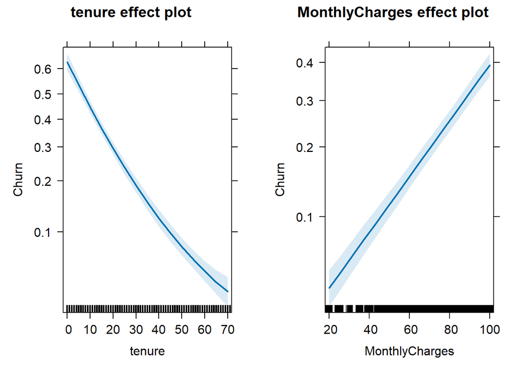

```r
plot(allEffects( mod_num6 )) ## We can see how tenure slope is smoothed in high tenure.
```

## Residual analysis

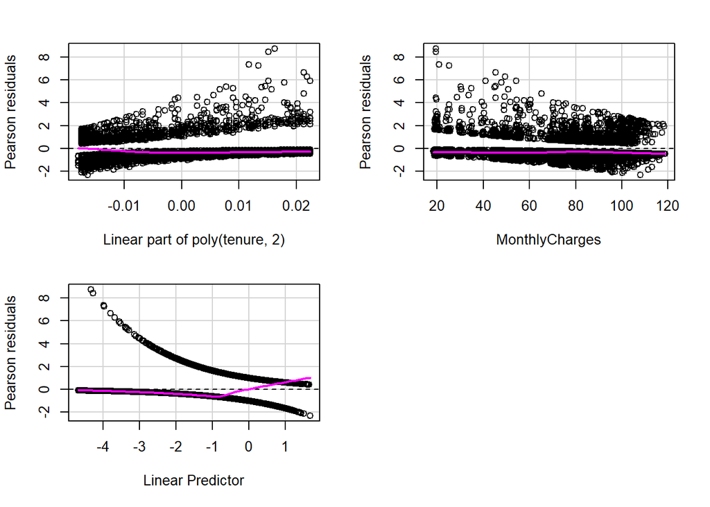

```
##                 Test stat Pr(>|Test stat|)
## poly(tenure, 2)
## MonthlyCharges     0.0565           0.8122
```

```r
residualPlots( mod_num6 )
```

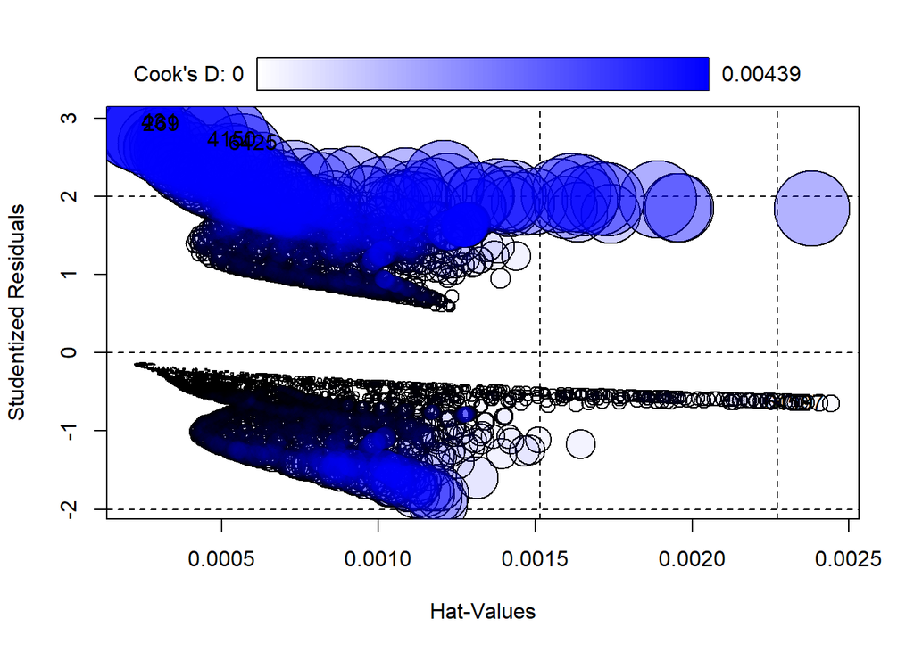

```
##         StudRes          Hat        CookD
## 6119 -0.6408156 0.0024069130 0.0001376051
## 269   2.9282222 0.0002283574 0.0040652746
## 4587 -0.6460006 0.0024426444 0.0001421684
## 4150  2.7261200 0.0004340039 0.0043156940
## 6425  2.6796931 0.0005017285 0.0043859131
## 431   2.9518147 0.0002246452 0.0042884924
```

```r
## Looks pretty flat some observations in low Monthly charges have higher residuals but is not normal as the predictor has positive correlation, so low Monthly charges with churn are less probable.

influencePlot( mod_num6 )
```

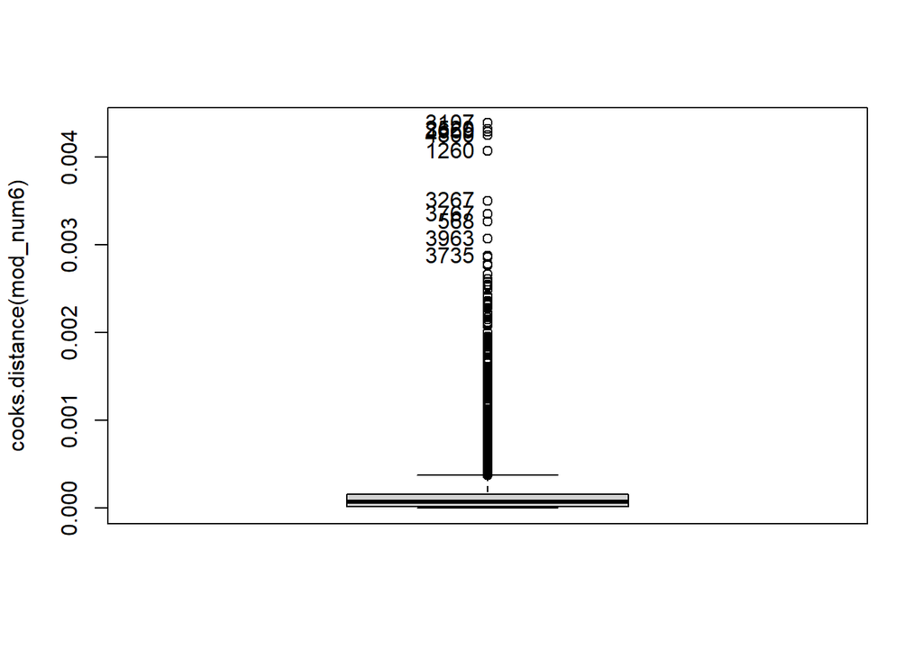

```
##  [1] 3107 2520 3669 4800 1260 3267 3767  568 3963 3735
```

```r
## There are some observations that have higher residuals than expected but are not very separate from each other. Let's check the boxplot

Boxplot(cooks.distance( mod_num6 ))
```

```r
## We have some influential values but it just because it is rare of low Monthly Charges to have a churn. We believe we should keep them in the dataset in order to not manipulate too much the model and have biased results.
```

## Adding factor main effects to the best model containing numeric variables

As a last step to create our model, we introduced all our categorical variables to the model and we run step() to remove non significant predictors. There are multiple variables that are very related with the level No Internet these generate the model to not converge in some betas. As the levels in these variables can be also categorized as No instead of No Internet Service. Also we will be able to aisle the effect of No Internet with the variable InternetService. If more NA generate all the variance will be captured with the variable InternetService or other variable.

After refactoring all the variables that were related to each other we can see that MonthlyCharges is dependent on some of the other variables. We will remove those which are not significant and check whether we should add them or not. With the anova test we can observe that the change is not significant so we can keep the small model with the principle of parsimony. Through the vif we can also see that the multicorrelation has reduced.

Finally, we show the effect plots of the features in the model so we are able to define which category of Churn is more likely to happen when the feature takes the different values.

```r
#train_new
mod <- glm(Churn ~ gender + SeniorCitizen +  Partner + Dependents + poly(tenure, 2) + MultipleLines + InternetService + OnlineSecurity + OnlineBackup + DeviceProtection + TechSupport + StreamingTV + StreamingMovies + Contract + PaperlessBilling + MonthlyCharges, data=train_new, family = binomial)
summary(mod)
```

```
##
## Call:
## glm(formula = Churn ~ gender + SeniorCitizen + Partner + Dependents +
##     poly(tenure, 2) + MultipleLines + InternetService + OnlineSecurity +
##     OnlineBackup + DeviceProtection + TechSupport + StreamingTV +
##     StreamingMovies + Contract + PaperlessBilling + MonthlyCharges,
##     family = binomial, data = train_new)
##
## Coefficients: (6 not defined because of singularities)
##                                      Estimate Std. Error z value Pr(>|z|)
## (Intercept)                          -0.18593    1.64965  -0.113 0.910259
## genderMale                           -0.05053    0.07444  -0.679 0.497271
## SeniorCitizen1                        0.23581    0.09668   2.439 0.014724 *
## PartnerYes                           -0.04925    0.08871  -0.555 0.578761
## DependentsYes                        -0.14202    0.10256  -1.385 0.166141
## poly(tenure, 2)1                    -48.46940    4.93448  -9.823  < 2e-16 ***
## poly(tenure, 2)2                     23.61501    3.21735   7.340 2.14e-13 ***
## MultipleLinesNo phone service        -0.07058    0.74559  -0.095 0.924582
## MultipleLinesYes                      0.46049    0.20430   2.254 0.024197 *
## InternetServiceFiber optic            1.70264    0.91938   1.852 0.064034 .
## InternetServiceNo                    -1.56283    0.92622  -1.687 0.091544 .
## OnlineSecurityNo internet service          NA         NA      NA       NA
## OnlineSecurityYes                    -0.20071    0.20616  -0.974 0.330284
## OnlineBackupNo internet service            NA         NA      NA       NA
## OnlineBackupYes                       0.01276    0.20251   0.063 0.949772
## DeviceProtectionNo internet service        NA         NA      NA       NA
## DeviceProtectionYes                   0.11152    0.20199   0.552 0.580874
## TechSupportNo internet service             NA         NA      NA       NA
## TechSupportYes                       -0.16038    0.20871  -0.768 0.442246
## StreamingTVNo internet service             NA         NA      NA       NA
## StreamingTVYes                        0.68356    0.37688   1.814 0.069720 .
## StreamingMoviesNo internet service         NA         NA      NA       NA
## StreamingMoviesYes                    0.64094    0.37613   1.704 0.088375 .
## ContractOne year                     -0.77209    0.12386  -6.233 4.56e-10 ***
## ContractTwo year                     -2.01393    0.22054  -9.132  < 2e-16 ***
## PaperlessBillingYes                   0.33076    0.08569   3.860 0.000113 ***
## MonthlyCharges                       -0.03076    0.03651  -0.842 0.399518
## ---
## Signif. codes:  0 '***' 0.001 '**' 0.01 '*' 0.05 '.' 0.1 ' ' 1
##
## (Dispersion parameter for binomial family taken to be 1)
##
##     Null deviance: 6171.2  on 5281  degrees of freedom
## Residual deviance: 4429.2  on 5261  degrees of freedom
## AIC: 4471.2
##
## Number of Fisher Scoring iterations: 6
```

```r
step_mod <- step(mod, trace=F)
summary(step_mod) ## There are multiple variables that are very related with the level No Internet these generate the model to not converge in some betas. As the levels in these variables can be also categorized as No instead of No Internet Service. Also we will be able to aisle the effect of No Internet with the variable InternetService. If more NA generate all the variance will be captured with the variable InternetService or other variable.
```

```
##
## Call:
## glm(formula = Churn ~ SeniorCitizen + Dependents + poly(tenure,
##     2) + MultipleLines + InternetService + OnlineSecurity + TechSupport +
##     StreamingTV + StreamingMovies + Contract + PaperlessBilling +
##     MonthlyCharges, family = binomial, data = train_new)
##
## Coefficients: (4 not defined because of singularities)
##                                     Estimate Std. Error z value Pr(>|z|)
## (Intercept)                         -0.72477    0.58603  -1.237 0.216187
## SeniorCitizen1                       0.23123    0.09612   2.406 0.016146 *
## DependentsYes                       -0.16577    0.09360  -1.771 0.076568 .
## poly(tenure, 2)1                   -49.21233    4.80315 -10.246  < 2e-16 ***
## poly(tenure, 2)2                    23.53228    3.21288   7.324 2.40e-13 ***
## MultipleLinesNo phone service        0.15021    0.27613   0.544 0.586463
## MultipleLinesYes                     0.40305    0.11079   3.638 0.000275 ***
## InternetServiceFiber optic           1.42884    0.31802   4.493 7.02e-06 ***
## InternetServiceNo                   -1.28719    0.35466  -3.629 0.000284 ***
## OnlineSecurityNo internet service         NA         NA      NA       NA
## OnlineSecurityYes                   -0.25551    0.11429  -2.236 0.025384 *
## TechSupportNo internet service            NA         NA      NA       NA
## TechSupportYes                      -0.21336    0.11783  -1.811 0.070183 .
## StreamingTVNo internet service            NA         NA      NA       NA
## StreamingTVYes                       0.57871    0.15661   3.695 0.000220 ***
## StreamingMoviesNo internet service        NA         NA      NA       NA
## StreamingMoviesYes                   0.53785    0.15476   3.475 0.000510 ***
## ContractOne year                    -0.76559    0.12361  -6.194 5.88e-10 ***
## ContractTwo year                    -2.00258    0.22004  -9.101  < 2e-16 ***
## PaperlessBillingYes                  0.32998    0.08556   3.857 0.000115 ***
## MonthlyCharges                      -0.01977    0.01192  -1.659 0.097137 .
## ---
## Signif. codes:  0 '***' 0.001 '**' 0.01 '*' 0.05 '.' 0.1 ' ' 1
##
## (Dispersion parameter for binomial family taken to be 1)
##
##     Null deviance: 6171.2  on 5281  degrees of freedom
## Residual deviance: 4430.6  on 5265  degrees of freedom
## AIC: 4464.6
##
## Number of Fisher Scoring iterations: 6
```

```r
train_new$OnlineBackup    <- train_new$OnlineBackup    %>% as.character()
train_new$OnlineSecurity    <- train_new$OnlineSecurity    %>% as.character()
train_new$DeviceProtection<- train_new$DeviceProtection %>% as.character()
train_new$TechSupport     <- train_new$TechSupport     %>% as.character()
train_new$StreamingTV     <- train_new$StreamingTV     %>% as.character()
train_new$StreamingMovies <- train_new$StreamingMovies %>% as.character()

train_new$OnlineBackup     <- ifelse(train_new$OnlineBackup == 'No internet service', 'No', train_new$OnlineBackup)
train_new$OnlineSecurity     <- ifelse(train_new$OnlineSecurity == 'No internet service', 'No', train_new$OnlineSecurity)
train_new$DeviceProtection <- ifelse(train_new$DeviceProtection == 'No internet service', 'No', train_new$DeviceProtection)
train_new$TechSupport      <- ifelse(train_new$TechSupport == 'No internet service', 'No', train_new$TechSupport)
train_new$StreamingTV      <- ifelse(train_new$StreamingTV == 'No internet service', 'No', train_new$StreamingTV)
train_new$StreamingMovies  <- ifelse(train_new$StreamingMovies == 'No internet service', 'No', train_new$StreamingTV)

train_new$OnlineBackup    <- train_new$OnlineBackup    %>% as.factor()
train_new$OnlineSecurity    <- train_new$OnlineSecurity    %>% as.factor()
train_new$DeviceProtection<- train_new$DeviceProtection %>% as.factor()
train_new$TechSupport     <- train_new$TechSupport     %>% as.factor()
train_new$StreamingTV     <- train_new$StreamingTV     %>% as.factor()
train_new$StreamingMovies <- train_new$StreamingMovies %>% as.factor()


mod2 <- glm(Churn ~ gender + SeniorCitizen +  Partner + Dependents + poly(tenure, 2) + MultipleLines + InternetService + OnlineSecurity + OnlineBackup + DeviceProtection + TechSupport + StreamingTV + Contract + PaperlessBilling + MonthlyCharges, data=train_new, family = binomial)

summary(mod2)
```

```
##
## Call:
## glm(formula = Churn ~ gender + SeniorCitizen + Partner + Dependents +
##     poly(tenure, 2) + MultipleLines + InternetService + OnlineSecurity +
##     OnlineBackup + DeviceProtection + TechSupport + StreamingTV +
##     Contract + PaperlessBilling + MonthlyCharges, family = binomial,
##     data = train_new)
##
## Coefficients:
##                                 Estimate Std. Error z value Pr(>|z|)
## (Intercept)                    -2.896568   0.440706  -6.573 4.95e-11 ***
## genderMale                     -0.052518   0.074402  -0.706 0.480274
## SeniorCitizen1                  0.235360   0.096630   2.436 0.014863 *
## PartnerYes                     -0.045129   0.088617  -0.509 0.610575
## DependentsYes                  -0.141823   0.102477  -1.384 0.166377
## poly(tenure, 2)1              -48.260650   4.930798  -9.788  < 2e-16 ***
## poly(tenure, 2)2               23.628029   3.216172   7.347 2.03e-13 ***
## MultipleLinesNo phone service   1.141370   0.225463   5.062 4.14e-07 ***
## MultipleLinesYes                0.160485   0.103575   1.549 0.121271
## InternetServiceFiber optic      0.197162   0.253541   0.778 0.436784
## InternetServiceNo              -0.057530   0.279600  -0.206 0.836981
## OnlineSecurityYes              -0.503244   0.105288  -4.780 1.76e-06 ***
## OnlineBackupYes                -0.289194   0.098300  -2.942 0.003262 **
## DeviceProtectionYes            -0.183167   0.104585  -1.751 0.079883 .
## TechSupportYes                 -0.463910   0.109343  -4.243 2.21e-05 ***
## StreamingTVYes                  0.090824   0.144934   0.627 0.530884
## ContractOne year               -0.771337   0.123828  -6.229 4.69e-10 ***
## ContractTwo year               -2.009535   0.220525  -9.113  < 2e-16 ***
## PaperlessBillingYes             0.336985   0.085581   3.938 8.23e-05 ***
## MonthlyCharges                  0.029601   0.008872   3.336 0.000848 ***
## ---
## Signif. codes:  0 '***' 0.001 '**' 0.01 '*' 0.05 '.' 0.1 ' ' 1
##
## (Dispersion parameter for binomial family taken to be 1)
##
##     Null deviance: 6171.2  on 5281  degrees of freedom
## Residual deviance: 4432.1  on 5262  degrees of freedom
## AIC: 4472.1
##
## Number of Fisher Scoring iterations: 6
```

```r
vif(mod2)
```

```
##                       GVIF Df GVIF^(1/(2*Df))
## gender            1.002976  1        1.001487
## SeniorCitizen     1.145921  1        1.070477
## Partner           1.367963  1        1.169600
## Dependents        1.274307  1        1.128852
## poly(tenure, 2)   2.674350  2        1.278806
## MultipleLines     5.631266  2        1.540464
## InternetService  26.960139  2        2.278665
## OnlineSecurity    1.337421  1        1.156469
## OnlineBackup      1.530548  1        1.237153
## DeviceProtection  1.710532  1        1.307873
## TechSupport       1.464988  1        1.210367
## StreamingTV       3.677450  1        1.917668
## Contract          1.779049  2        1.154907
## PaperlessBilling  1.127854  1        1.062005
## MonthlyCharges   42.016372  1        6.482004
```

```r
## After refactoring all the variables that were related to each other we can see that MonthlyCharges is dependent on some of the other variables. We will remove those which are not significant and check whether we should add them or not.


Anova(mod2, test="LR")
```

```
## Analysis of Deviance Table (Type II tests)
##
## Response: Churn
##                  LR Chisq Df Pr(>Chisq)
## gender              0.498  1  0.4802756
## SeniorCitizen       5.920  1  0.0149664 *
## Partner             0.259  1  0.6106298
## Dependents          1.922  1  0.1656116
## poly(tenure, 2)   226.114  2  < 2.2e-16 ***
## MultipleLines      33.592  2  5.076e-08 ***
## InternetService     0.790  2  0.6736513
## OnlineSecurity     23.205  1  1.456e-06 ***
## OnlineBackup        8.671  1  0.0032335 **
## DeviceProtection    3.070  1  0.0797302 .
## TechSupport        18.222  1  1.966e-05 ***
## StreamingTV         0.393  1  0.5308566
## Contract          114.051  2  < 2.2e-16 ***
## PaperlessBilling   15.596  1  7.840e-05 ***
## MonthlyCharges     11.194  1  0.0008207 ***
## ---
## Signif. codes:  0 '***' 0.001 '**' 0.01 '*' 0.05 '.' 0.1 ' ' 1
```

```r
mod3 <- glm(Churn ~ SeniorCitizen +  poly(tenure, 2) + MultipleLines + OnlineSecurity + OnlineBackup + TechSupport + Contract + PaperlessBilling + MonthlyCharges, data=train_new, family = binomial)
Anova(mod3, test="LR")
```

```
## Analysis of Deviance Table (Type II tests)
##
## Response: Churn
##                  LR Chisq Df Pr(>Chisq)
## SeniorCitizen       7.795  1  0.0052386 **
## poly(tenure, 2)   263.346  2  < 2.2e-16 ***
## MultipleLines      64.374  2  1.050e-14 ***
## OnlineSecurity     33.037  1  9.043e-09 ***
## OnlineBackup       12.465  1  0.0004146 ***
## TechSupport        27.842  1  1.316e-07 ***
## Contract          130.953  2  < 2.2e-16 ***
## PaperlessBilling   17.011  1  3.716e-05 ***
## MonthlyCharges    298.361  1  < 2.2e-16 ***
## ---
## Signif. codes:  0 '***' 0.001 '**' 0.01 '*' 0.05 '.' 0.1 ' ' 1
```

```r
anova(mod3, mod2, test="Chisq") ## It is not significant so we can keep the small model with the principle of parsimony.
```

```
## Analysis of Deviance Table
##
## Model 1: Churn ~ SeniorCitizen + poly(tenure, 2) + MultipleLines + OnlineSecurity +
##     OnlineBackup + TechSupport + Contract + PaperlessBilling +
##     MonthlyCharges
## Model 2: Churn ~ gender + SeniorCitizen + Partner + Dependents + poly(tenure,
##     2) + MultipleLines + InternetService + OnlineSecurity + OnlineBackup +
##     DeviceProtection + TechSupport + StreamingTV + Contract +
##     PaperlessBilling + MonthlyCharges
##   Resid. Df Resid. Dev Df Deviance Pr(>Chi)
## 1      5269     4442.2
## 2      5262     4432.1  7   10.097   0.1832
```

```r
vif(mod3) ## The multicorrelation has reduced.
```

```
##                      GVIF Df GVIF^(1/(2*Df))
## SeniorCitizen    1.096933  1        1.047346
## poly(tenure, 2)  2.432127  2        1.248811
## MultipleLines    1.922042  2        1.177445
## OnlineSecurity   1.098729  1        1.048203
## OnlineBackup     1.260452  1        1.122698
## TechSupport      1.164474  1        1.079108
## Contract         1.698638  2        1.141629
## PaperlessBilling 1.121320  1        1.058924
## MonthlyCharges   2.260157  1        1.503382
```

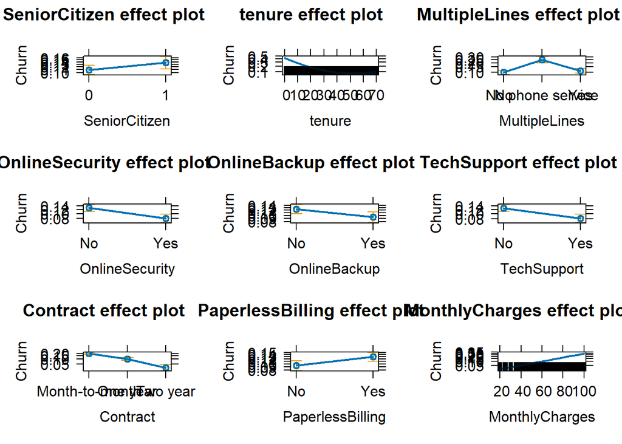

```r
plot(allEffects(mod3))
```

## Residual analysis with categorical variables

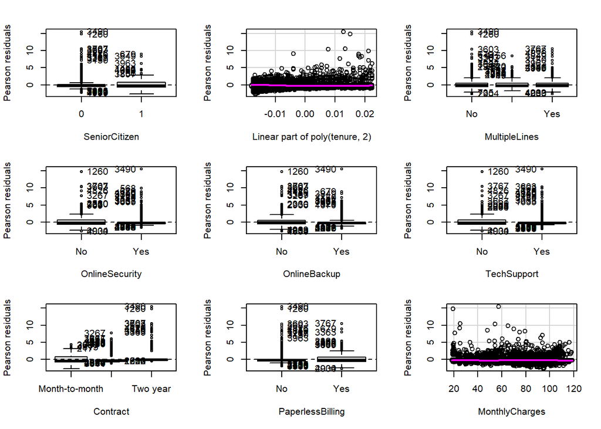

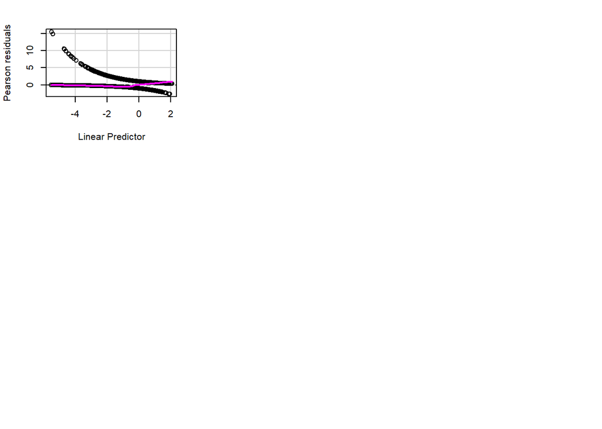

```
##                  Test stat Pr(>|Test stat|)
## SeniorCitizen
## poly(tenure, 2)
## MultipleLines
## OnlineSecurity
## OnlineBackup
## TechSupport
## Contract
## PaperlessBilling
## MonthlyCharges      0.4256           0.5142
```

```r
residualPlots(mod3)
```

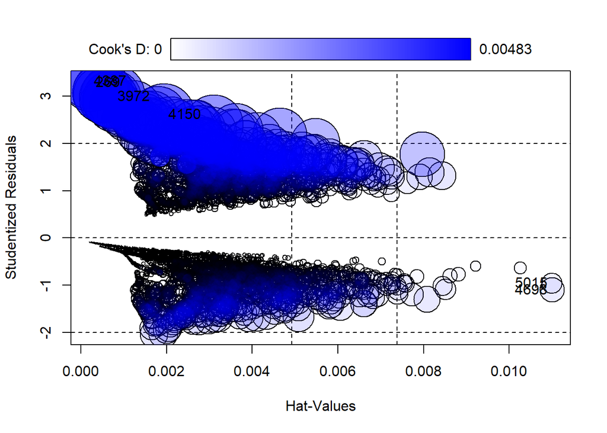

```
##        StudRes          Hat        CookD
## 5015 -0.954685 0.0109996750 0.0004950570
## 269   3.290572 0.0002419871 0.0040538545
## 4150  2.614033 0.0019388313 0.0042864608
## 4387  3.318092 0.0002008891 0.0036955404
## 4698 -1.093540 0.0110005478 0.0007008811
## 3972  2.989649 0.0007499970 0.0048288428
```

```r
influencePlot(mod3)
```

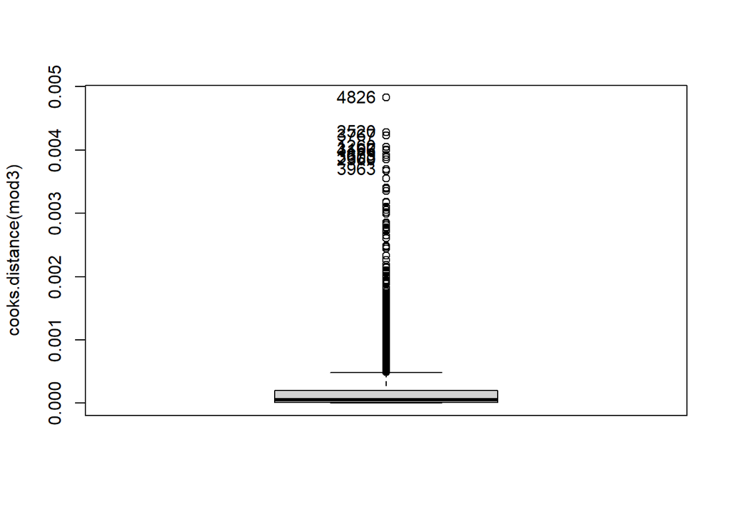

```r
cook <- Boxplot(cooks.distance(mod3))
```

```r
cookd <- sort(cooks.distance(mod3)[cook], decreasing=TRUE)
cookd
```

```
##        3972        4150        4273         269        6425        6814
## 0.004828843 0.004286461 0.004231198 0.004053854 0.004003822 0.003998106
##        6725        5590        4528        4514
## 0.003920864 0.003884925 0.003849025 0.003696433
```

```r
length(rownames(train_new) %in% names(cookd)) #[1] 5282
```

```
## [1] 5282
```

## Factor interactions

Now, we are searching for interactions between factors in the model, beginning by testing some combinations of variables that had sense for us to have relation between them. We identify the one that yields the best results. But, given the high quantity of variables, manually exploring combinations becomes impractical. Hence, we employ the iterative stepwise method to check different combinations. The iteration providing the best results includes interactions between OnlineSecurity and TechSupport with a high representation, and MultipleLines and TechSupport with minimal representation. We tested the one with more representation alone, and then with both interactions to assess any significant improvement. However, there is no significant change observed, leading us to choose the simpler model, mod7.

```r
mod4 <- glm(Churn ~ SeniorCitizen +  poly(tenure, 2) + MultipleLines + OnlineSecurity + OnlineBackup + TechSupport + Contract * PaperlessBilling + MonthlyCharges, data=train_new, family = binomial)

anova(mod3, mod4, test="Chisq")
```

```
## Analysis of Deviance Table
##
## Model 1: Churn ~ SeniorCitizen + poly(tenure, 2) + MultipleLines + OnlineSecurity +
##     OnlineBackup + TechSupport + Contract + PaperlessBilling +
##     MonthlyCharges
## Model 2: Churn ~ SeniorCitizen + poly(tenure, 2) + MultipleLines + OnlineSecurity +
##     OnlineBackup + TechSupport + Contract * PaperlessBilling +
##     MonthlyCharges
##   Resid. Df Resid. Dev Df Deviance Pr(>Chi)
## 1      5269     4442.2
## 2      5267     4441.7  2  0.54682   0.7608
```

```r
mod5 <- glm(Churn ~ SeniorCitizen +  poly(tenure, 2) + (MultipleLines + OnlineSecurity + OnlineBackup + TechSupport)*MonthlyCharges + Contract + PaperlessBilling, data=train_new, family = binomial)

anova(mod3, mod5, test="Chisq")
```

```
## Analysis of Deviance Table
##
## Model 1: Churn ~ SeniorCitizen + poly(tenure, 2) + MultipleLines + OnlineSecurity +
##     OnlineBackup + TechSupport + Contract + PaperlessBilling +
##     MonthlyCharges
## Model 2: Churn ~ SeniorCitizen + poly(tenure, 2) + (MultipleLines + OnlineSecurity +
##     OnlineBackup + TechSupport) * MonthlyCharges + Contract +
##     PaperlessBilling
##   Resid. Df Resid. Dev Df Deviance Pr(>Chi)
## 1      5269     4442.2
## 2      5264     4437.4  5   4.7964   0.4412
```

```r
mod6 <- glm(Churn ~ SeniorCitizen +  poly(tenure, 2) + (MultipleLines + OnlineSecurity + OnlineBackup + TechSupport + MonthlyCharges)^2 + Contract + PaperlessBilling, data=train_new, family = binomial)

step_mod <- step(mod6, trace=F) # muchas variables como para ver sus combinaciones por eso utilizamos el metodo iterativo stepwise
summary(step_mod)
```

```
##
## Call:
## glm(formula = Churn ~ SeniorCitizen + poly(tenure, 2) + MultipleLines +
##     OnlineSecurity + OnlineBackup + TechSupport + MonthlyCharges +
##     Contract + PaperlessBilling + MultipleLines:TechSupport +
##     OnlineSecurity:TechSupport, family = binomial, data = train_new)
##
## Coefficients:
##                                                Estimate Std. Error z value
## (Intercept)                                   -3.145537   0.157115 -20.021
## SeniorCitizen1                                 0.259451   0.094679   2.740
## poly(tenure, 2)1                             -50.582871   4.767564 -10.610
## poly(tenure, 2)2                              23.668432   3.226857   7.335
## MultipleLinesNo phone service                  1.289467   0.158374   8.142
## MultipleLinesYes                               0.130584   0.104482   1.250
## OnlineSecurityYes                             -0.681131   0.113830  -5.984
## OnlineBackupYes                               -0.322770   0.089409  -3.610
## TechSupportYes                                -0.631772   0.156778  -4.030
## MonthlyCharges                                 0.033872   0.002073  16.341
## ContractOne year                              -0.817754   0.121860  -6.711
## ContractTwo year                              -2.145683   0.222457  -9.645
## PaperlessBillingYes                            0.345041   0.085413   4.040
## MultipleLinesNo phone service:TechSupportYes  -0.527034   0.320468  -1.645
## MultipleLinesYes:TechSupportYes                0.092769   0.193980   0.478
## OnlineSecurityYes:TechSupportYes               0.477683   0.202415   2.360
##                                              Pr(>|z|)
## (Intercept)                                   < 2e-16 ***
## SeniorCitizen1                               0.006138 **
## poly(tenure, 2)1                              < 2e-16 ***
## poly(tenure, 2)2                             2.22e-13 ***
## MultipleLinesNo phone service                3.89e-16 ***
## MultipleLinesYes                             0.211365
## OnlineSecurityYes                            2.18e-09 ***
## OnlineBackupYes                              0.000306 ***
## TechSupportYes                               5.58e-05 ***
## MonthlyCharges                                < 2e-16 ***
## ContractOne year                             1.94e-11 ***
## ContractTwo year                              < 2e-16 ***
## PaperlessBillingYes                          5.35e-05 ***
## MultipleLinesNo phone service:TechSupportYes 0.100058
## MultipleLinesYes:TechSupportYes              0.632478
## OnlineSecurityYes:TechSupportYes             0.018279 *
## ---
## Signif. codes:  0 '***' 0.001 '**' 0.01 '*' 0.05 '.' 0.1 ' ' 1
##
## (Dispersion parameter for binomial family taken to be 1)
##
##     Null deviance: 6171.2  on 5281  degrees of freedom
## Residual deviance: 4432.6  on 5266  degrees of freedom
## AIC: 4464.6
##
## Number of Fisher Scoring iterations: 6
```

```r
mod7 <- glm(Churn ~ SeniorCitizen +  poly(tenure, 2) + MultipleLines + OnlineSecurity*TechSupport + OnlineBackup + MonthlyCharges + Contract + PaperlessBilling, data=train_new, family = binomial)

anova(mod3, mod7, test="Chisq")
```

```
## Analysis of Deviance Table
##
## Model 1: Churn ~ SeniorCitizen + poly(tenure, 2) + MultipleLines + OnlineSecurity +
##     OnlineBackup + TechSupport + Contract + PaperlessBilling +
##     MonthlyCharges
## Model 2: Churn ~ SeniorCitizen + poly(tenure, 2) + MultipleLines + OnlineSecurity *
##     TechSupport + OnlineBackup + MonthlyCharges + Contract +
##     PaperlessBilling
##   Resid. Df Resid. Dev Df Deviance Pr(>Chi)
## 1      5269     4442.2
## 2      5268     4436.7  1   5.5334  0.01866 *
## ---
## Signif. codes:  0 '***' 0.001 '**' 0.01 '*' 0.05 '.' 0.1 ' ' 1
```

```r
mod8 <- glm(Churn ~ SeniorCitizen +  poly(tenure, 2) + (MultipleLines + OnlineSecurity)*TechSupport + OnlineBackup + MonthlyCharges + Contract + PaperlessBilling, data=train_new, family = binomial)

anova(mod7, mod8, test="Chisq") # no cambio significant, nos quedamos con el simple mod7
```

```
## Analysis of Deviance Table
##
## Model 1: Churn ~ SeniorCitizen + poly(tenure, 2) + MultipleLines + OnlineSecurity *
##     TechSupport + OnlineBackup + MonthlyCharges + Contract +
##     PaperlessBilling
## Model 2: Churn ~ SeniorCitizen + poly(tenure, 2) + (MultipleLines + OnlineSecurity) *
##     TechSupport + OnlineBackup + MonthlyCharges + Contract +
##     PaperlessBilling
##   Resid. Df Resid. Dev Df Deviance Pr(>Chi)
## 1      5268     4436.7
## 2      5266     4432.6  2    4.068   0.1308
```

## Residual analysis with the best model

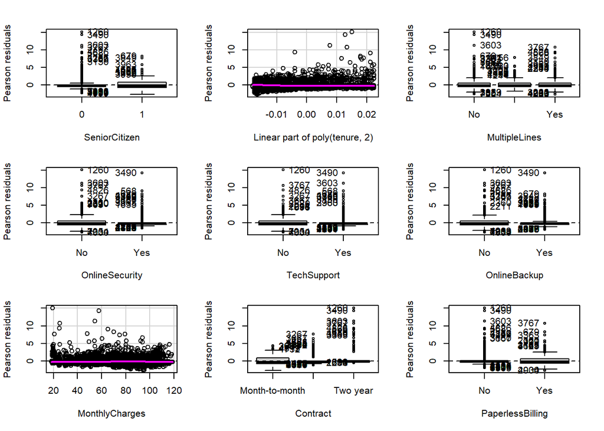

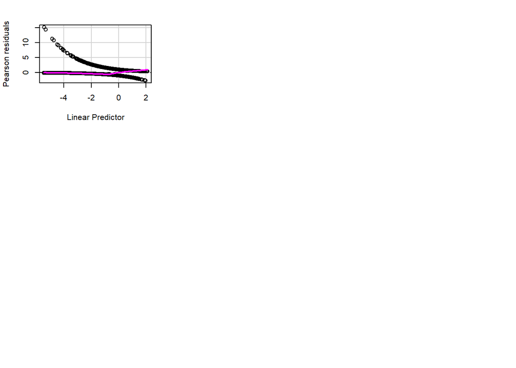

```
##                  Test stat Pr(>|Test stat|)
## SeniorCitizen
## poly(tenure, 2)
## MultipleLines
## OnlineSecurity
## TechSupport
## OnlineBackup
## MonthlyCharges      0.2991           0.5844
## Contract
## PaperlessBilling
```

```r
residualPlots(mod7)
```

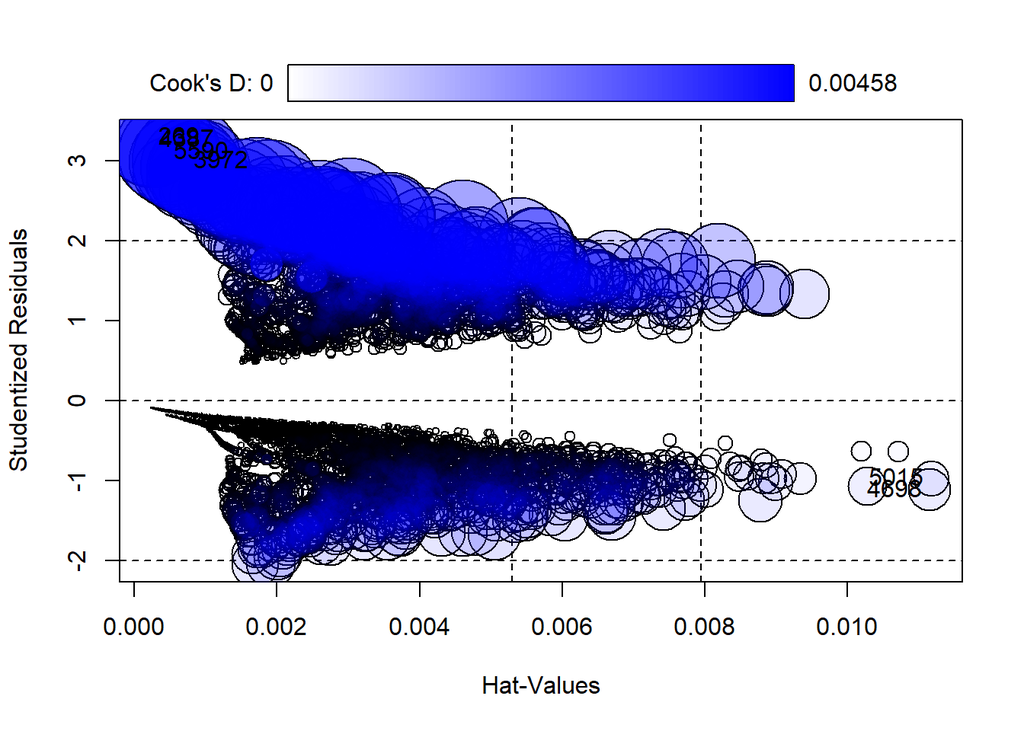

```
##         StudRes          Hat        CookD
## 5015 -0.9669999 0.0111716287 0.0004821169
## 269   3.3050018 0.0002356469 0.0038429673
## 4387  3.2718677 0.0002489926 0.0036447601
## 5590  3.1264571 0.0004481656 0.0040966086
## 4698 -1.1103032 0.0111496498 0.0006869491
## 3972  3.0060673 0.0007301710 0.0045848121
```

```r
influencePlot(mod7)
```

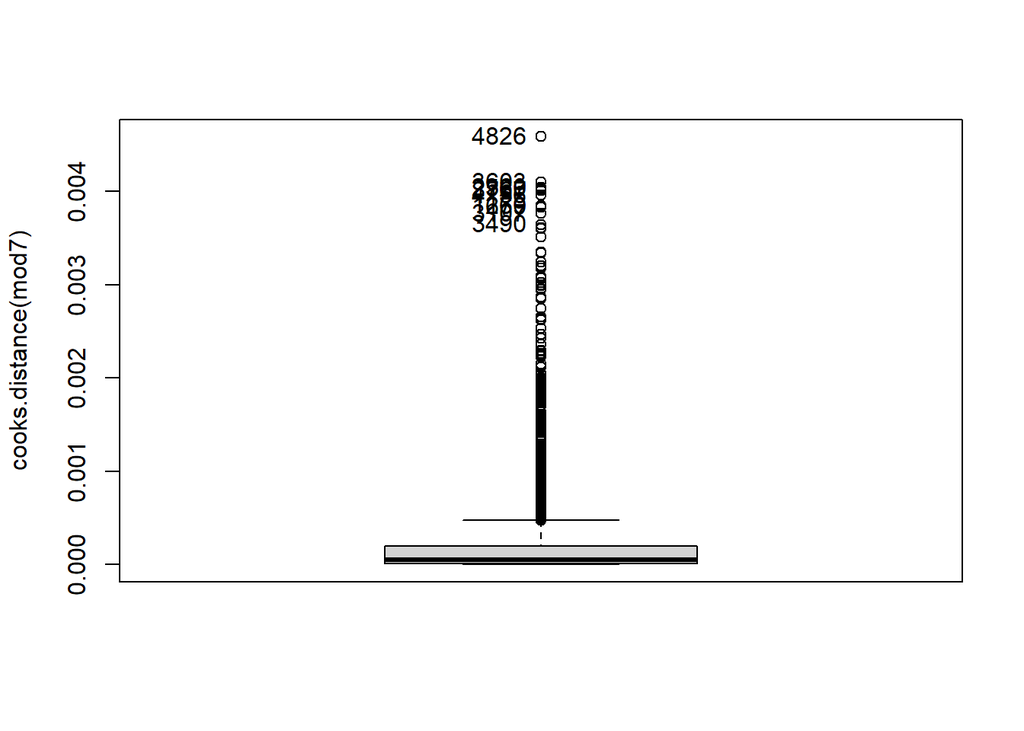

```r
cook <- Boxplot(cooks.distance(mod7))
```

```r
cookd <- sort(cooks.distance(mod7)[cook], decreasing=TRUE)
cookd
```

```
##        3972        5590        4528        4150        4273        6814
## 0.004584812 0.004096609 0.004038624 0.004026787 0.004008097 0.003957548
##         269        6725        6425        4387
## 0.003842967 0.003832726 0.003761736 0.003644760
```

```r
length(rownames(train_new) %in% names(cookd)) #[1] 5282
```

```
## [1] 5282
```

## Model Interpretation and residual analysis

```r
summary(mod7)
```

```
##
## Call:
## glm(formula = Churn ~ SeniorCitizen + poly(tenure, 2) + MultipleLines +
##     OnlineSecurity * TechSupport + OnlineBackup + MonthlyCharges +
##     Contract + PaperlessBilling, family = binomial, data = train_new)
##
## Coefficients:
##                                    Estimate Std. Error z value Pr(>|z|)
## (Intercept)                       -3.142762   0.156737 -20.051  < 2e-16 ***
## SeniorCitizen1                     0.261661   0.094745   2.762 0.005749 **
## poly(tenure, 2)1                 -50.095970   4.742029 -10.564  < 2e-16 ***
## poly(tenure, 2)2                  23.855515   3.211963   7.427 1.11e-13 ***
## MultipleLinesNo phone service      1.163172   0.141899   8.197 2.46e-16 ***
## MultipleLinesYes                   0.149771   0.094602   1.583 0.113384
## OnlineSecurityYes                 -0.682007   0.113778  -5.994 2.04e-09 ***
## TechSupportYes                    -0.646185   0.114362  -5.650 1.60e-08 ***
## OnlineBackupYes                   -0.321563   0.089315  -3.600 0.000318 ***
## MonthlyCharges                     0.033880   0.002066  16.395  < 2e-16 ***
## ContractOne year                  -0.818931   0.121691  -6.730 1.70e-11 ***
## ContractTwo year                  -2.152023   0.221340  -9.723  < 2e-16 ***
## PaperlessBillingYes                0.350968   0.085270   4.116 3.86e-05 ***
## OnlineSecurityYes:TechSupportYes   0.477552   0.202089   2.363 0.018124 *
## ---
## Signif. codes:  0 '***' 0.001 '**' 0.01 '*' 0.05 '.' 0.1 ' ' 1
##
## (Dispersion parameter for binomial family taken to be 1)
##
##     Null deviance: 6171.2  on 5281  degrees of freedom
## Residual deviance: 4436.7  on 5268  degrees of freedom
## AIC: 4464.7
##
## Number of Fisher Scoring iterations: 6
```

```r
vif(mod7)
```

```
## there are higher-order terms (interactions) in this model
## consider setting type = 'predictor'; see ?vif
```

```
##                                GVIF Df GVIF^(1/(2*Df))
## SeniorCitizen              1.097232  1        1.047489
## poly(tenure, 2)            2.448750  2        1.250939
## MultipleLines              1.924345  2        1.177798
## OnlineSecurity             1.586071  1        1.259393
## TechSupport                1.625500  1        1.274951
## OnlineBackup               1.264149  1        1.124344
## MonthlyCharges             2.270735  1        1.506896
## Contract                   1.754205  2        1.150854
## PaperlessBilling           1.122019  1        1.059254
## OnlineSecurity:TechSupport 2.158190  1        1.469078
```

```r
exp(mod7$coefficients)
```

```
##                      (Intercept)                   SeniorCitizen1
##                     4.316340e-02                     1.299086e+00
##                 poly(tenure, 2)1                 poly(tenure, 2)2
##                     1.752252e-22                     2.292549e+10
##    MultipleLinesNo phone service                 MultipleLinesYes
##                     3.200069e+00                     1.161568e+00
##                OnlineSecurityYes                   TechSupportYes
##                     5.056011e-01                     5.240411e-01
##                  OnlineBackupYes                   MonthlyCharges
##                     7.250153e-01                     1.034460e+00
##                 ContractOne year                 ContractTwo year
##                     4.409028e-01                     1.162488e-01
##              PaperlessBillingYes OnlineSecurityYes:TechSupportYes
##                     1.420442e+00                     1.612123e+00
```

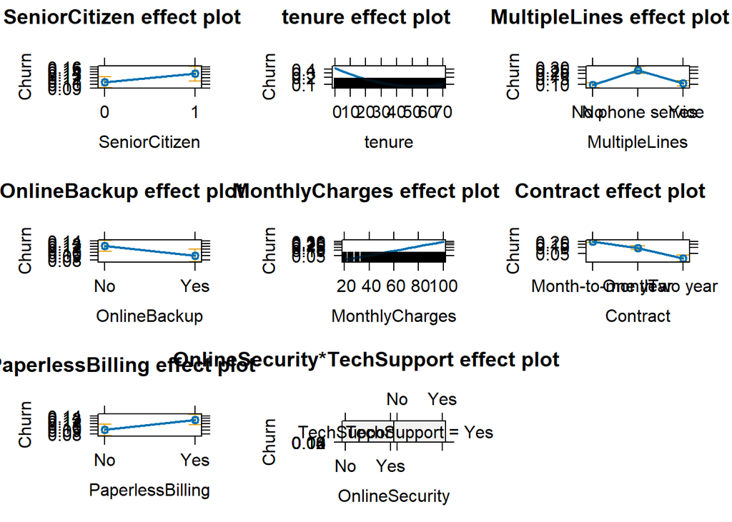

```r
par(mfrow=c(1,2))
plot(allEffects(mod = mod7))
```

```r
#avPlots(mod7) #es como el effect
sum( resid( mod7, "pearson") ^2 )
```

```
## [1] 5607.608
```

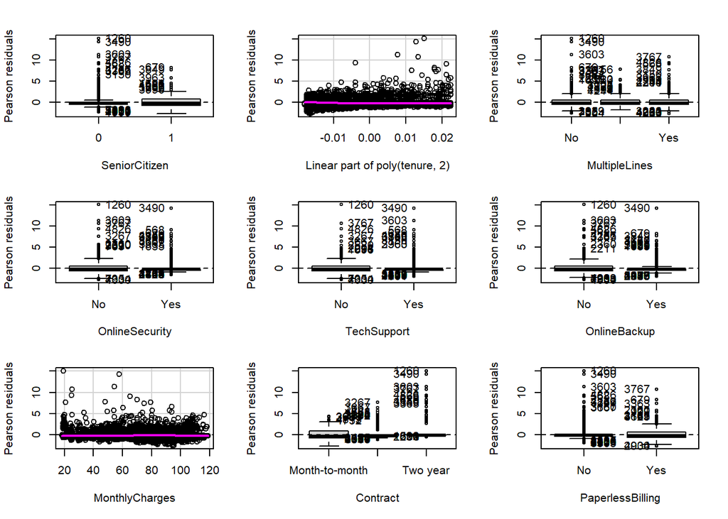

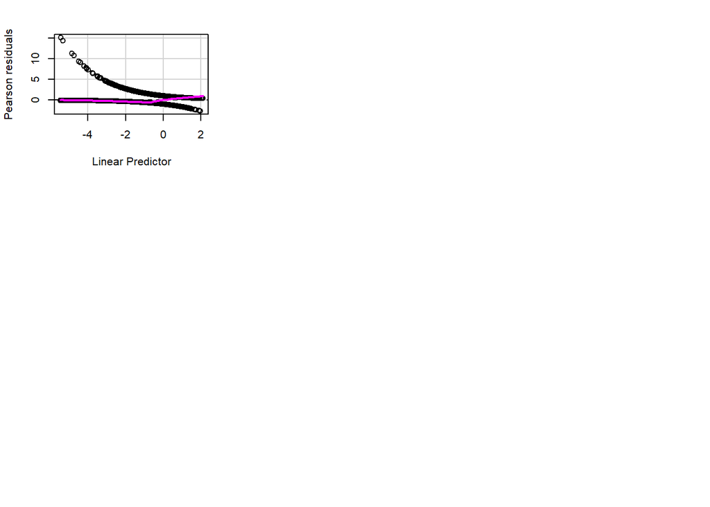

```
##                  Test stat Pr(>|Test stat|)
## SeniorCitizen
## poly(tenure, 2)
## MultipleLines
## OnlineSecurity
## TechSupport
## OnlineBackup
## MonthlyCharges      0.2991           0.5844
## Contract
## PaperlessBilling
```

```r
residualPlots(mod7)
```

The final model has this form.

$$\begin{align*}
y = & -3.1427 \alpha + \beta_{\text{SeniorCitizen1}} 0.26 +
\beta_{\text{tenure}} (-50.09) + \beta_{\text{tenure}^2} 23.85 \\
& + \beta_{\text{MultipleLinesNo phone service}} 1.16 +
\beta_{\text{MultipleLinesYes}} 0.14 + \beta_{\text{OnlineSecurityYes}}
(-0.68) \\
& + \beta_{\text{TechSupportYes}} (-0.64) +
\beta_{\text{OnlineBackupYes}} (-0.32) + \beta_{\text{MonthlyCharges}}
0.03 \\
& + \beta_{\text{ContractOne year}} (-0.81) +
\beta_{\text{ContractTwo year}} (-2.15) +
\beta_{\text{PaperlessBillingYes}} 0.35 \\
& + \beta_{\text{OnlineSecurityYes:TechSupportYes}} 0.47
\end{align*}$$

From the effects plots and the betas we can draw the following conclusions:

- Senior Citizen are more likely to Churn than no Senior Citizens as the have an odds of 1.3 against non senior citizens.
- We can understand tenure very easily thanks to the plot of effects. We can see how old clients of the company (old in terms of months in the company) are less probable to live the company although it smoothes this behaviour as the client reaches 40 months, this is a very important variable in order to explain churns.
- Those clients who don’t have a phone service have an odds of 3.2 for leaving compared to those who only have 1 line.
- The clients who have Online Backup are less likely to live the company, with an odds of 0.72 compared to those who have not.
- Monthly charges has a linear relation with the probability of Churn, in other words, the probability of leaving is higher as the Montly Charges become higher. The odds of leaving for every unit of Monthly Charges is 1.0344. This is also a very important variable in our model.
- Those clients which have a shorter contract effect are more prone to leave than the others. We can see how the odds of leaving for Two year effect contracts is 0.11 compared to Month-to-Month. So the probability of leaving for those who have month-to-month contract are 9 times higher.
- Paperless Billing has also an effect with an odds ratio of 1.42 of yes against no.
- Lastly we can check the effect of the interaction between Online Security and Tech Support. If the client has Tech Support will be less likely to leave, otherwise will be more likely to leave, especially if she/he has not Online Security either.

Residual analysis:

We can see the effects on having an unbalanced dataset in our residual/Goodness of fit analysis. We can interpret from the plots that our residuals are far more likely to have extreme positive values rather than negative ones. In fact they are very related to the conclusions of the model interpretation. As the combination of variables gets more prone to not churn we will see more influential values in the positive axis.

### Standarize test

```r
test_new$OnlineBackup    <- test_new$OnlineBackup    %>% as.character()
test_new$OnlineSecurity    <- test_new$OnlineSecurity    %>% as.character()
test_new$DeviceProtection<- test_new$DeviceProtection %>% as.character()
test_new$TechSupport     <- test_new$TechSupport     %>% as.character()
test_new$StreamingTV     <- test_new$StreamingTV     %>% as.character()
test_new$StreamingMovies <- test_new$StreamingMovies %>% as.character()

test_new$OnlineBackup     <- ifelse(test_new$OnlineBackup == 'No internet service', 'No', test_new$OnlineBackup)
test_new$OnlineSecurity     <- ifelse(test_new$OnlineSecurity == 'No internet service', 'No', test_new$OnlineSecurity)
test_new$DeviceProtection <- ifelse(test_new$DeviceProtection == 'No internet service', 'No', test_new$DeviceProtection)
test_new$TechSupport      <- ifelse(test_new$TechSupport == 'No internet service', 'No', test_new$TechSupport)
test_new$StreamingTV      <- ifelse(test_new$StreamingTV == 'No internet service', 'No', test_new$StreamingTV)
test_new$StreamingMovies  <- ifelse(test_new$StreamingMovies == 'No internet service', 'No', test_new$StreamingTV)

test_new$OnlineBackup    <- test_new$OnlineBackup    %>% as.factor()
test_new$OnlineSecurity    <- test_new$OnlineSecurity    %>% as.factor()
test_new$DeviceProtection<- test_new$DeviceProtection %>% as.factor()
test_new$TechSupport     <- test_new$TechSupport     %>% as.factor()
test_new$StreamingTV     <- test_new$StreamingTV     %>% as.factor()
test_new$StreamingMovies <- test_new$StreamingMovies %>% as.factor()
```

### Goodness of fit

```r
final_model <- mod7
dim(test_new)
```

```
## [1] 1761   23
```

```r
predictions <- predict(final_model,test_new, type="response")
test_new$PredictedChurn <- ifelse(predictions > 0.5,"Yes","No") %>% as.factor
val <- table(test_new$PredictedChurn, test_new$Churn)

table(test_new$PredictedChurn)
```

```
##
##   No  Yes
## 1399  362
```

```r
table(test_new$Churn)
```

```
##
##   No  Yes
## 1323  438
```

```r
val %>% kableExtra::kable()
```

|  | No | Yes |
| --- | --- | --- |
| No | 1210 | 189 |
| Yes | 113 | 249 |

```r
accuracy <- sum(diag(val))/sum(val)
TP <- val[2,2]
FN <- val[1,2]
FP <- val[2,1]

accuracy <- sum(diag(val))/sum(val)
Recall <- TP/(TP+FN)
Precision <- TP / (TP + FP)
F1 <- 2 * (Precision * Recall) / (Precision + Recall)

GOF <- rbind(accuracy, Recall, Precision, F1)
colnames(GOF) <- "Metrics"
GOF %>% round(2) %>% kableExtra::kable()
```

|  | Metrics |
| --- | --- |
| accuracy | 0.83 |
| Recall | 0.57 |
| Precision | 0.69 |
| F1 | 0.62 |

```r
library("ROCR")
```

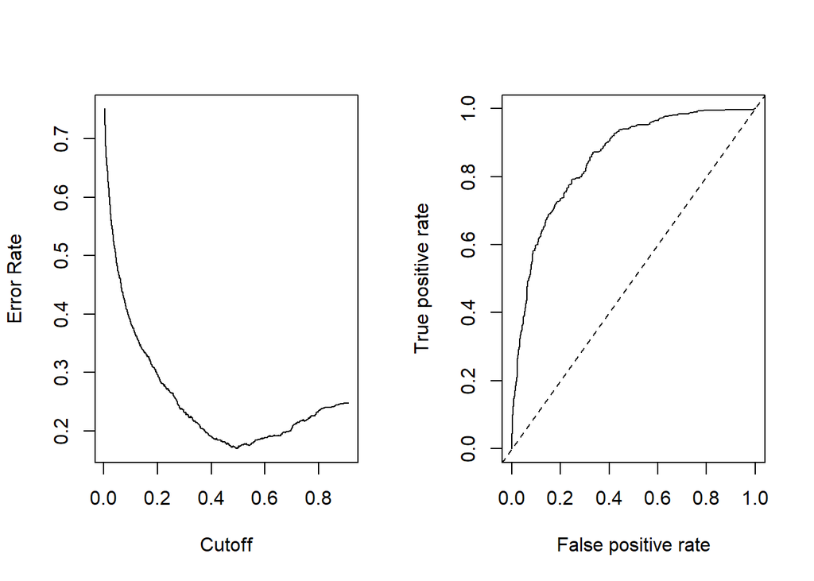

```r
dadesroc<-prediction(predict(final_model, newdata = test_new,type="response"),test_new$Churn)
par(mfrow=c(1,2))
plot(performance(dadesroc,"err"))
plot(performance(dadesroc,"tpr","fpr"))
abline(0,1,lty=2)
```

```r
predictions <- predict(final_model,test_new, type="response")
test_new$PredictedChurn <- ifelse(predictions > 0.4,"Yes","No") %>% as.factor
val <- table(test_new$PredictedChurn, test_new$Churn)

table(test_new$PredictedChurn)
```

```
##
##   No  Yes
## 1263  498
```

```r
table(test_new$Churn)
```

```
##
##   No  Yes
## 1323  438
```

```r
TP <- val[2,2]
FN <- val[1,2]
FP <- val[2,1]

accuracy <- sum(diag(val))/sum(val)
Recall <- TP/(TP+FN)
Precision <- TP / (TP + FP)
F1 <- 2 * (Precision * Recall) / (Precision + Recall)

GOF <- rbind(accuracy, Recall, Precision, F1)
colnames(GOF) <- "Metrics"
GOF %>% round(2) %>% kableExtra::kable()
```

|  | Metrics |
| --- | --- |
| accuracy | 0.81 |
| Recall | 0.68 |
| Precision | 0.60 |
| F1 | 0.64 |

```r
 ## F1 improves so we will keep the second threshold
```